# QMM7301 Case Study 1

## Introduction

In QMM7300 and QMM 7301 we’ve collected personalized data to analyze. I collected data on my daily habits for **7 variables** over **154 days** in the Summer and Fall 2025 semesters.

I have collected a variety of data since May 12 outlining aspects of my daily routine. The variables are tabularized below along with the data type.

| Variable | Type |
| --- | --- |
| Date (mm/dd/yyyy) | Identifier |
| Class (yes/no) | Qualitative - Nominal |
| Studying (hrs) | Quantitative - Continuous |
| Trade Stocks Today (yes/no) | Qualitative - Nominal |
| Stocks Satisfaction (1 to 5) | Qualitative - Ordinal |
| Number of stocks (#) | Quantitative - Discrete |
| Cum Stocks Value (USD) | Quantitative - Continuous |
| Semester (S25/F25) | Qualitative - Nominal |

I’ll be utilizing the following variables to answer three questions

- What do I do in a day
- Do I spend the days how I expect
- Is there any difference in how I spend this semester from how I spent last semester

First Let’s analyze all the quantitative variables in a nice table

```
##            Stat.type Study.hours Firms.Invested Stocks.value
## 1               Mean    2.600649      3.9545455     364.9492
## 2             Median    2.500000      4.0000000     364.6150
## 3 Standard Deviation    1.644341      0.4761077      25.2227
## 4                IQR    1.875000      0.0000000       3.6075
```

Okay, lets see if the four conditions are met to use the t-distribution. Let’s recap. What **are** the **4** conditions

- 1. Independence Assumption
- 2. Randomization Condition
- 3. 10% Condition
- 4. Nearly Normal Condition

[figure not shown]

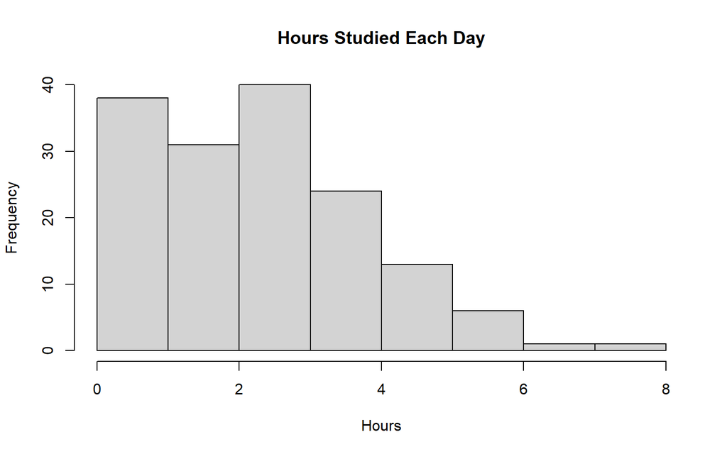

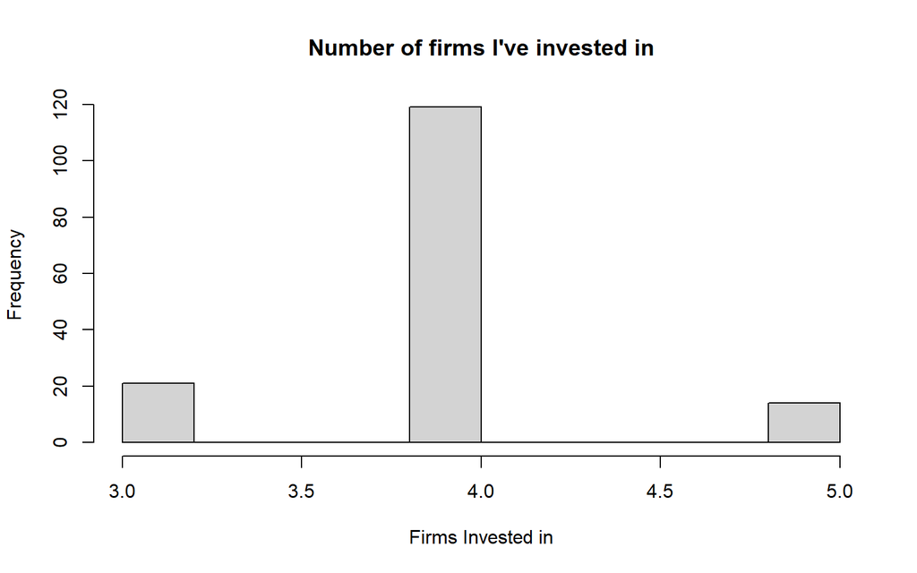

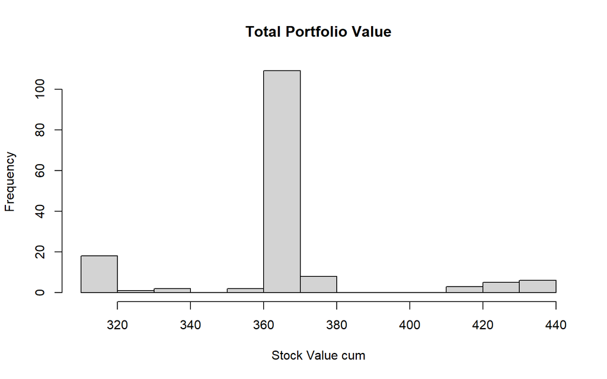

- Study Hours

| Condition | Met | Notes |
| --- | --- | --- |
| 1 | No | –> Not Independent. We’ll be doing a paired test |
| 2 | No | –> Same person being studied affects randomness |
| 3 | Yes | –> Not really Checked |
| 4 | Yes | –> Histogram all over the place, but we’ll assume yes |

- Firms Invested In

| Condition | Met | Notes |
| --- | --- | --- |
| 1 | No | –> Not Independent. Values are based on previous ones |
| 2 | No | –> Same person being studied affects randomness |
| 3 | Yes | –> Not really Checked |
| 4 | Yes | –> Unimodal |

- Cumulative value of Stocks

| Condition | Met | Notes |
| --- | --- | --- |
| 1 | Yes | –> I don’t control the market |
| 2 | No | –> Same person being studied affects randomness |
| 3 | Yes | –> Not really Checked |
| 4 | Yes | –> Unimodal |

## Data Analysis

### Part 1: Confidence Intervals

Let’s take a look at the confidence intervals of my quantitative variables

- Study Hours ⬇️

The 95% confidence interval is between 2.3388743, 2.8624244 hours.

Interpretation: We can be 95% confident that my true average study hours across both semesters is between 2.3 and 2.8 Hours This makes sense, I put in more effort during the midterms and finals. Also, the NFL season began this September, I’m sure I reduced the amount of times I spent studying on weekends as a result of that. I also got job on campus, so I definitely reduced the amount of time I spent studying on weekdays. And… the gym!! I go four times a week now… 🏋️🏋️🏋️ That could account for the low value for the intervals.

- Firms Invested In ⬇️

The 95% confidence interval is between 3.8787502, 4.0303407 number of firms.

Interpretation: We can be 95% confident that the true average of the numbers of firms I invested in is between 3.8 and 4. This is a weird variable to study this way, but it tallies. I got rid of 1 low performing stock late last semester. I’m quite risk averse in a way. The stocks I have left are stable but don’t generate the most returns.

- Cumulative value of Stocks ⬇️

Interpretation: We can be 95% confident that the true average value of my portfolio is between 361 and 369 across the two semesters. Not really making any money here 🤷 I’ll be pivoting to investing in my projects. Perhaps those could generate the revenue I need.

### Part 2: One-Sample Hypothesis Tests

I’m going to test a hypothesis that on average, I study more than 3.13 hours a day (I’m pretty sure, I don’t)
$$H_0: μ Study Hours = 3.13hours\\
H_A: μ Study Hours > 3.13 Hours$$
We’ll utilize a t-test in r to test for this with 𝛼 of 0.05

With a p value of 0.9999499 We fail to reject the null There isn’t sufficient evidence that my mean study hours is greater than 3.13 hours

I do practice what i learn a lot, however. I’m currently working on a few projects where I utilize some of my python and web development skills. Should that count as as studying too? 🤔🤔🤔

Let’s do a t-test for my discrete quantitative variable. The number of firms I’ve invested in According to Statistics Canada’s 2022 Canadian Financial Capability Survey, the average number of individual stock holdings per Canadian investor is roughly 6-7 stocks per investor. I’m going to test that on average, i have fewer stocks than the average Canadian investor (I obviously do)
$$H_0: μ NumberOf StockHoldings = 7\\
H_A: μ NumberOf StockHoldings < 7$$

With𝛼 of 0.05

With a p value of 1.5473819^{-126}

We reject the null. There is sufficient evident to show that my portfolio has less than 7 companies

Let’s now do a t-test for my continuous quantitative variable. The cumulative value of my stocks. I want to see if the average value of my stocks is greater than $350. The amount I need to purchase a plane ticket in December.

$$H_0: μ CumSumOf Stocks = 350\\
H_A: μ CumSumOf Stocks > 350$$

The p-value from performing the test at $\alpha = 0.05$ is 5.4116116^{-12}

We reject reject the null. There is evidence that my cumulative stock value is greater than 350$ –The problem is finding the funds to leave Sudbury. Alternatively, I should take the time to actually explore Subbuty, maybe see the lakes everyone’s always mentioning

### Part 3: Two-Sample Hypothesis Tests

First, we’ll create a subset my records. Divide them into the summer semester and the fall semester
$$\text{Groupings: Summer Semester & Fall Semester}$$

**Note** Independence does not hold here. My sampling groups are not independent of each other. Whichever way, we’ll have to choose to do the paired t-test.

I’ve taken a random sample of 10 days from both semesters. i want to see if there’s any difference in the amount of hours I spend studying in the Summer Semester and the Fall Semester. I’m choosing to it this way to include a two-sided test

I’ll be using the paired t-test here. It violates the independence condition. Doesn’t matter that I randomly selected 10 rows. ‘d’ below refers to the difference in the means of my study hours

$$H_0: μ_d=Δ_0 \\
H_A: μ_d≠Δ_0$$

With a p-value of 0.7428339 which is greater than 𝛼 of 0.05 We fail to reject the null. There is insufficient evidence to conclude that my mean study hours differ between the two semesters.

This is weird. I must have under counted my study hours during the summer semester.

Next, i want to perform the same test across the first ten days of each semester. Again, I’ll use a paired t-test.

This one is way more straight forward. It violates the independence condition. It’s more of a direct difference test consisting of the first ten days of each sample. The same hypothesis applies.

$$H_0: μ_d=Δ_0 \\
H_A: μ_d≠Δ_0$$

With a p-value of 0.7163449 which is greater than 𝛼 of 0.05 We fail to reject the null. There is insufficient evidence to conclude that my mean study hours differ between the two semesters.

Well, my projects have come to a stall. Haven’t really coded much. Turns out, I always find the time to study, I guess. Creature of habit.

## Conclusion

I do a lot in a day. I find time for both work and play. Being health conscious has me going to the gym more. I thankfully got a job, so I don’t have as much time working on my side hustles as much.

I do spend the days how i expect to. Working and studying. I carve out time on the weekends to watch the NFL. I’m glad it’s still the redular season, once the playoffs come, I’ll be all in.

I think a part of me has settled on how much time I need to study. there is no statistical difference in my study hours across two semesters.

I think I know myself well enough to know how and when to study. Plus I’ve become one of those people that keeps a calendar so I’ve become a bit more organized.